# Between sample/beta diversity of Microbes by gut section

Calla Bush St George

2024-05-17

# Goals

1. Load in phyloseq data with rooted tree.
2. Evaluate sequencing depth and remove sample.
3. Normalize the read counts between samples.
4. Calculate community dissimilarities. Numbers between 0 and 1. If 0, completely similar versus if they are 1, then they are completely dissimilar.
   1. *Sorensen*: Presence/ Absence. Weighted by number of shared taxa. Shared species as a binary-valye. Abundance-unweighted.
   2. *Bray-Curtis*: Relative abundance. Weighted by number of shared taxa. Shared abundant species: abundance weighted.
   3. *(Abundance) Weighted UNIFRAC*: Consider abundant species and where they fall on the tree.
5. Visualize the community data with two unconstricted ordinations:
   1. *PCoA*: Linear method. Uses matrix algebra to calculate eigenvalye. Calculate how much variation is explained by each axis. Can choose to view axis 1, 2, 3, etc. and plot them together.
   2. *NMDS*: Non-linear method. Collapse multiple axes into two (or three) dimensions. Can see more axes of variation into fewer axes. Always need to report a stress value. (Ideally less than 0.15)
6. Run statistics with PERMANOVA and betadispR.

# Setup

## Load Libraries

```r
#install.packages("vegan")
pacman::p_load(tidyverse, devtools, phyloseq, patchwork, vegan, ggplot2,
               install = FALSE)
```

## Load in colors

```r
host_colors <- c(
  "Pomacanthus sexstriatus" = "navy",
  "Kyphosus sydneyanus" = "darkslategray2",
  "Kyphosus cinerascens" = "deeppink1",
  "Kyphosus vaigiensis" = "gold")
```

## Load in data

```r
# Load in rooted phylogenetic tree!
load("combined_data/data/03_Phylogenetic_Tree/phytree_preprocessed_physeq.RData")
unrooted_physeq
```

```
## phyloseq-class experiment-level object
## otu_table()   OTU Table:         [ 3390 taxa and 52 samples ]
## sample_data() Sample Data:       [ 52 samples by 24 sample variables ]
## tax_table()   Taxonomy Table:    [ 3390 taxa by 9 taxonomic ranks ]
## phy_tree()    Phylogenetic Tree: [ 3390 tips and 3388 internal nodes ]
```

```r
midroot_physeq
```

```
## phyloseq-class experiment-level object
## otu_table()   OTU Table:         [ 3389 taxa and 52 samples ]
## sample_data() Sample Data:       [ 52 samples by 24 sample variables ]
## tax_table()   Taxonomy Table:    [ 3389 taxa by 9 taxonomic ranks ]
## phy_tree()    Phylogenetic Tree: [ 3389 tips and 3388 internal nodes ]
```

# Explore Read Counts

## Raw Read Depth

```r
# Sequence depth will inform us on how we want to normalize our data
# Calculate the total number of reads per sample
raw_total_seqs_df <-
  unrooted_physeq %>%
  # Calculate the sample read sums
  sample_sums() %>%
  data.frame()

# Name the column
colnames(raw_total_seqs_df)[1] <- "TotalSeqs"

head(raw_total_seqs_df)
```

```
##       TotalSeqs
## 568_4     24522
## 568_5     17036
## 581_5     15067
## 611_5     13671
## E03_5      6828
## E1_4      43946
```

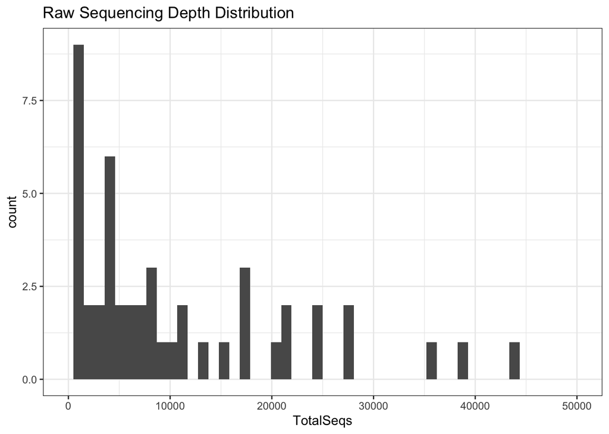

```r
# Make a histogram of raw reads
raw_seqs_histogram <-
  raw_total_seqs_df %>%
  ggplot(aes(x = TotalSeqs)) +
  geom_histogram(bins = 50) +
  scale_x_continuous(limits = c(0, 50000)) +
  labs(title = "Raw Sequencing Depth Distribution") +
  theme_bw()

raw_seqs_histogram
```

## Remove lowly sequenced sample

```r
raw_rooted_physeq <-
  midroot_physeq %>%
  # Remove lowly sequence sample that was outlier in alpha diversity analysis
  subset_samples(Run != "G197_IV") %>%
  subset_samples(Run != "SRR17060829") %>%
  subset_samples(Run != "SRR17060839") %>%
  subset_samples(Run != "SRR17060845") %>%
  subset_samples(Run != "G196_IV") %>%
  # Any ASVs unique to the sample will also be removed
  prune_taxa(taxa_sums(.) > 0, .)

# Inspect
raw_rooted_physeq
```

```
## phyloseq-class experiment-level object
## otu_table()   OTU Table:         [ 3206 taxa and 47 samples ]
## sample_data() Sample Data:       [ 47 samples by 24 sample variables ]
## tax_table()   Taxonomy Table:    [ 3206 taxa by 9 taxonomic ranks ]
## phy_tree()    Phylogenetic Tree: [ 3206 tips and 3205 internal nodes ]
```

```r
# What is the minimum number of sequences
raw_rooted_physeq %>%
  sample_sums() %>%
  min()
```

```
## [1] 526
```

## Normalize Read Counts

```r
### scale_reads function and matround function
####################################################################################
# Function to scale reads: http://deneflab.github.io/MicrobeMiseq/
# Scales reads by
# 1) taking proportions
# 2) multiplying by a given library size of n
# 3) rounding
# Default for n is the minimum sample size in your library
# Default for round is floor

matround <- function(x){trunc(x+0.5)}

scale_reads <- function(physeq, n = min(sample_sums(physeq)), round = "round") {

  # transform counts to n
  physeq.scale <- transform_sample_counts(physeq, function(x) {(n * x/sum(x))})

  # Pick the rounding functions
  if (round == "floor"){
    otu_table(physeq.scale) <- floor(otu_table(physeq.scale))
  } else if (round == "round"){
    otu_table(physeq.scale) <- round(otu_table(physeq.scale))
  } else if (round == "matround"){
    otu_table(physeq.scale) <- matround(otu_table(physeq.scale))
  }

  # Prune taxa and return new phyloseq object
  physeq.scale <- prune_taxa(taxa_sums(physeq.scale) > 0, physeq.scale)
  return(physeq.scale)

  }
```

This is where one might decide to use rarefaction to normalize the data.

## Scale reads and check the distribution of the seq depth

```r
min(sample_sums(raw_rooted_physeq))
```

```
## [1] 526
```

```r
# Scale reads by the above function
scaled_rooted_physeq <-
  raw_rooted_physeq %>%
  scale_reads(round = "matround")

# Calculate read depth
## Look at total number of sequences in each sample and compare to what we had before

scaled_total_seqs_df <-
  scaled_rooted_physeq %>%
  sample_sums() %>%
  data.frame()

head(scaled_total_seqs_df)
```

```
##         .
## 568_4 522
## 568_5 503
## 581_5 494
## 611_5 517
## E03_5 513
## E1_4  523
```

```r
# Change first column name to be "TotalSeqs"
colnames(scaled_total_seqs_df)[1] <- "TotalSeqs"

# Inspect
head(scaled_total_seqs_df)
```

```
##       TotalSeqs
## 568_4       522
## 568_5       503
## 581_5       494
## 611_5       517
## E03_5       513
## E1_4        523
```

```r
# Check range of data
min_seqs <-
  min(scaled_total_seqs_df)
max_seqs <-
 max(scaled_total_seqs_df)
# Range of seqs
max_seqs - min_seqs
```

```
## [1] 81
```

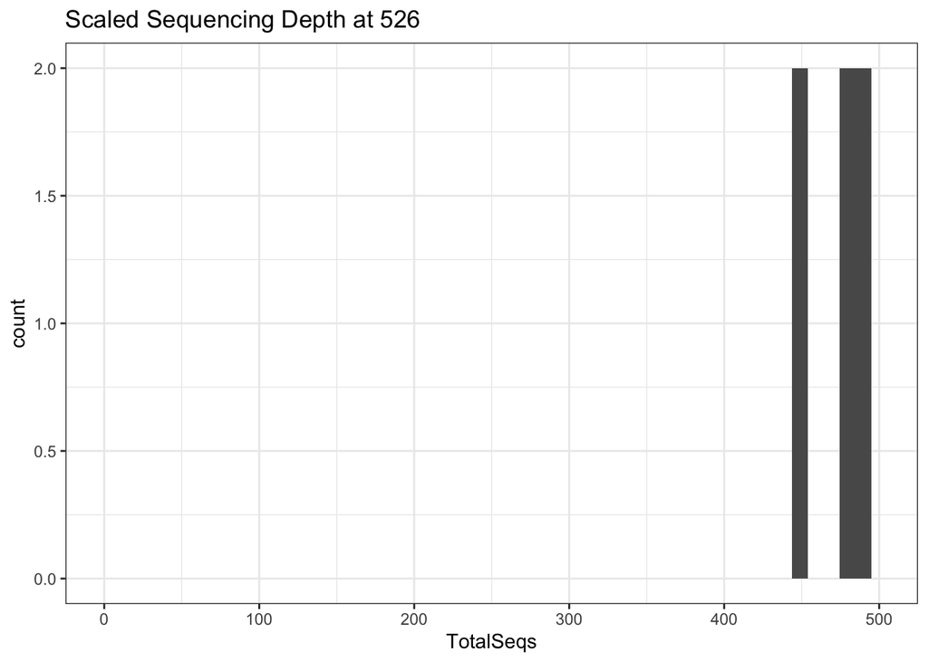

```r
# Plot histogram
scaled_total_seqs_df %>%
  ggplot(aes(x = TotalSeqs)) +
  geom_histogram(bins = 50) +
  scale_x_continuous(limits = c(0, 500)) +
  labs(title = "Scaled Sequencing Depth at 526") +
  theme_bw()
```

```r
head(scaled_total_seqs_df)
```

```
##       TotalSeqs
## 568_4       522
## 568_5       503
## 581_5       494
## 611_5       517
## E03_5       513
## E1_4        523
```

# Calculate & Visualize Community Dissimiliarity

Exploratory analyses from the Paily & Shankar (2016) paper, which is using unconstrained ordination methods like PCoA.

## Sorenson PCoA

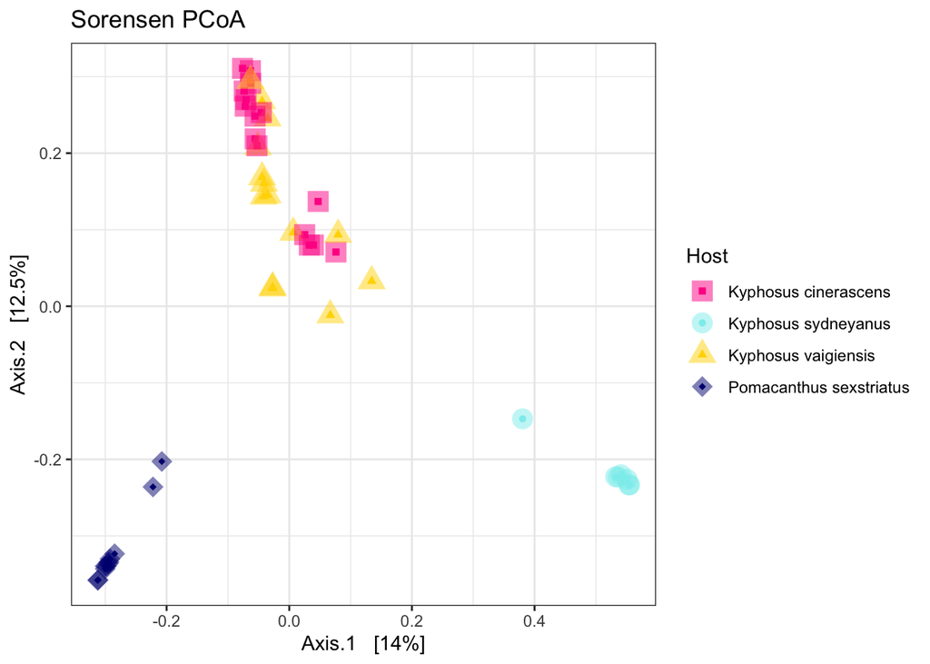

```r
# Calculate sorenson dissimularity: Abundance-unweighted of shared taxa
scaled_soren_pcoa <-
  ordinate(
    physeq = scaled_rooted_physeq,
    method = "PCoA",
    distance = "bray", binary = TRUE)


# Plot the ordination
soren_host_pcoa <- plot_ordination(
  physeq = scaled_rooted_physeq,
  ordination = scaled_soren_pcoa,
  color = "Host",
  shape = "Host",
  title = "Sorensen PCoA") +
  geom_point(size=5, alpha = 0.5, aes(color = Host)) +
  scale_shape_manual(values = c(15,16,17,18)) +
  scale_color_manual(values = host_colors) +
  theme_bw()
# Show the plot
soren_host_pcoa
```

Here, we are evaluating the shared taxa by presence/absence (abundance-unweighted) in the Sorensen metric.

Note that:

- Axis 1 = ~14% of variation
- Axis 2 = ~13% of variation

This means we explain 27% of the variation in the data in these two axes.

## Bray-Curtis PCoA

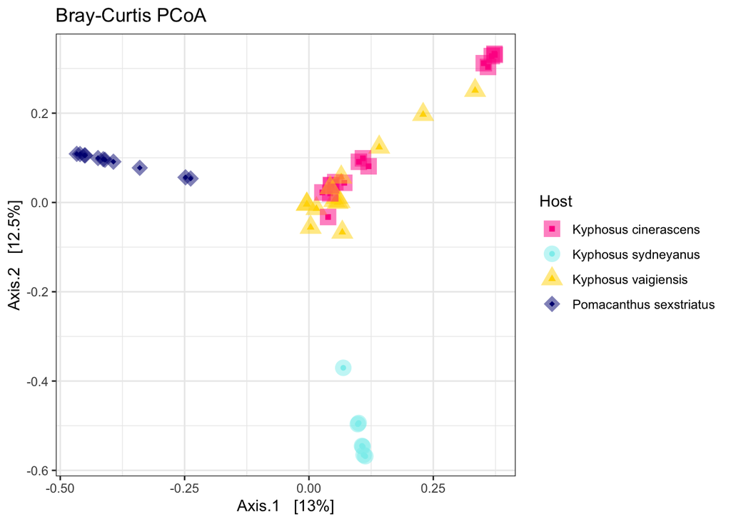

```r
# Calculate the BC distance
scaled_BC_pcoa <-
  ordinate(
    physeq = scaled_rooted_physeq,
    method = "PCoA",
    distance = "bray")

# Plot the PCoA
bray_host_pcoa <-
  plot_ordination(
    physeq = scaled_rooted_physeq,
    ordination = scaled_BC_pcoa,
    color = "Host",
    shape = "Host",
    title = "Bray-Curtis PCoA") +
  geom_point(size=5, alpha = 0.5, aes(color = Host)) +
  scale_shape_manual(values = c(15,16,17,18)) +
  scale_color_manual(values = c(host_colors)) +
  theme_bw()
bray_host_pcoa
```

Here, we are evaluating the shared taxa and then weighting them by their abundances, which provides more influence for species that are more abundant.

Note that:

- Axis 1 = ~13% of variation
- Axis 2 = ~13% of variation

## Weighted-Unifrac PCoA

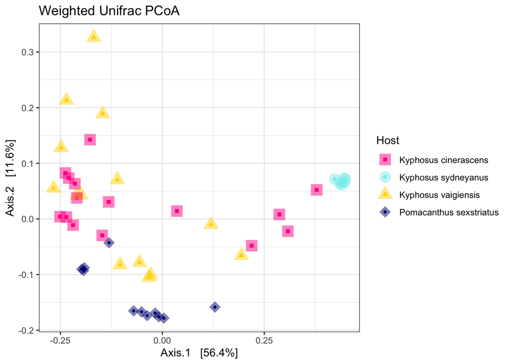

```r
# Calculate the BC distance
scaled_wUNI_pcoa <-
  ordinate(
    physeq = scaled_rooted_physeq,
    method = "PCoA",
    distance = "wunifrac")

# Plot the PCoA
wUNI_host_pcoa <-
  plot_ordination(
    physeq = scaled_rooted_physeq,
    ordination = scaled_wUNI_pcoa,
    color = "Host",
    shape = "Host",
    title = "Weighted Unifrac PCoA") +
  geom_point(size=5, alpha = 0.5, aes(color = Host)) +
  scale_shape_manual(values = c(15,16,17,18)) +
  scale_color_manual(values = c(host_colors)) +
  theme_bw()
wUNI_host_pcoa
```

Here, we are evaluating the shared taxa and then weighting them by their abundances, which provides more influence for species that are more abundant.

Note that:

- Axis 1 = ~56% of variation
- Axis 2 = ~12% of variation

This means we explain *68*% of the variation in the data in these two axes (!!!), which is significantly more than the previous plots with the taxonomic dissimilarity measures.

## NMDS

### Weighted Unifrac

Since we did 3 of the dissimilarity metrics for the PCoA, let’s just plot one example of them for the NMDS plotting. Here, we will use weighted Unifrac

```r
# Calculate the Weighted Unifrac distance
scaled_wUNI_nmds <-
  ordinate(
    physeq = scaled_rooted_physeq,
    method = "NMDS",
    distance = "wunifrac")
```

```
## *** Best solution was not repeated -- monoMDS stopping criteria:
##     19: stress ratio > sratmax
##      1: scale factor of the gradient < sfgrmin
```

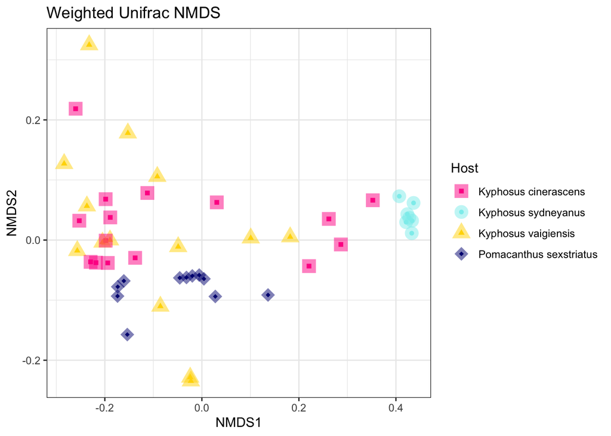

```r
# Plot the PCoA on host
wUNI_host_nmds <-
  plot_ordination(
    physeq = scaled_rooted_physeq,
    ordination = scaled_wUNI_nmds,
    color = "Host",
    shape = "Host",
    title = "Weighted Unifrac NMDS") +
  geom_point(size=5, alpha = 0.5, aes(color = Host)) +
  scale_shape_manual(values = c(15,16,17,18,19)) +
  scale_color_manual(values = c(host_colors)) +
  theme_bw()
wUNI_host_nmds
```

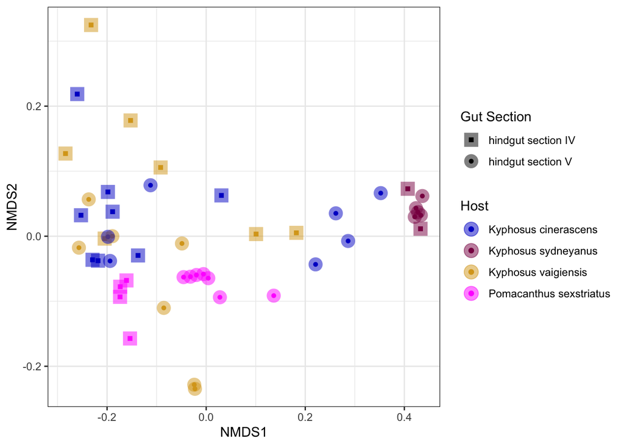

```r
# Plot the PCoA on gut section
wUNI_gut_section_nmds <-
  plot_ordination(
    physeq = scaled_rooted_physeq,
    ordination = scaled_wUNI_nmds,
    color = "Host",
    shape = "env_local_scale") +
  geom_point(size=5, alpha = 0.5, aes(color = Host)) +
  scale_shape_manual(values = c(15,16,17,18,19,20)) +
  scale_color_manual(values = c("blue3", "deeppink4", "goldenrod", "magenta")) +
  theme_bw() + labs(shape = "Gut Section")
wUNI_gut_section_nmds
```

In this case, I would always prefer to report the PCoA results because they are linear and provide a lot more post-hoc analyses to follow up with. In addition, it’s helpful to only have 2 axes of variation and show how much variation is explained.

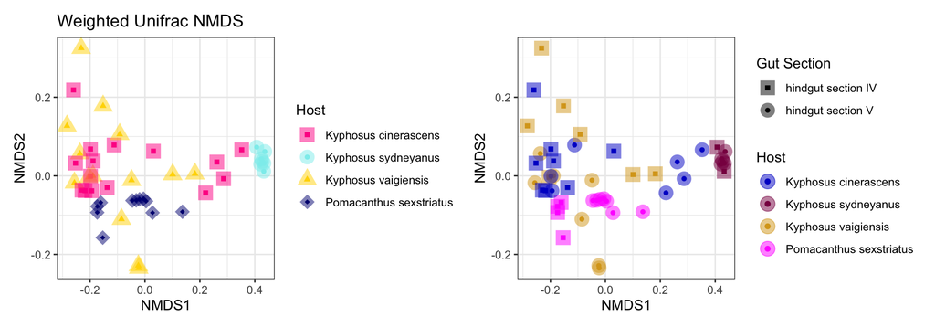

```r
(wUNI_host_nmds + theme(legend.position = "right")) +
  (wUNI_gut_section_nmds + theme(legend.position = "right"))
```

# Statistical Significance Testing

## PERMANOVA

```r
# Calculate all three of the distance matrices
scaled_wUnifrac_dist <- phyloseq::distance(scaled_rooted_physeq, method = "wunifrac")

# make a data frame from the sample_data
# All distance matrices will be the same metadata because they
# originate from the same phyloseq object.
metadata <- data.frame(sample_data(scaled_rooted_physeq))

# Adonis test
# In this example we are testing the hypothesis that the five stations
# that were collected have different centroids in the ordination space
# for each of the dissimilarity metrics, we are using a discrete variable
adonis2(scaled_wUnifrac_dist ~ Host, data = metadata)
```

```
## Permutation test for adonis under reduced model
## Terms added sequentially (first to last)
## Permutation: free
## Number of permutations: 999
##
## adonis2(formula = scaled_wUnifrac_dist ~ Host, data = metadata)
##          Df SumOfSqs      R2      F Pr(>F)
## Host      3   2.1647 0.44915 11.687  0.001 ***
## Residual 43   2.6549 0.55085
## Total    46   4.8196 1.00000
## ---
## Signif. codes:  0 '***' 0.001 '**' 0.01 '*' 0.05 '.' 0.1 ' ' 1
```

```r
adonis2(scaled_wUnifrac_dist ~ env_local_scale, data = metadata)
```

```
## Permutation test for adonis under reduced model
## Terms added sequentially (first to last)
## Permutation: free
## Number of permutations: 999
##
## adonis2(formula = scaled_wUnifrac_dist ~ env_local_scale, data = metadata)
##                 Df SumOfSqs     R2      F Pr(>F)
## env_local_scale  1   0.3962 0.0822 4.0305  0.011 *
## Residual        45   4.4234 0.9178
## Total           46   4.8196 1.0000
## ---
## Signif. codes:  0 '***' 0.001 '**' 0.01 '*' 0.05 '.' 0.1 ' ' 1
```

Note that:

- R2 = the percent variation explained.
- F = the F-Statistic, which represents the importance value.
- Pr(>F) = the pvalue

## BetaDispR

The PERMANOVA is sensitive to variance/dispersion in the data. Therefore, we need to run a homogeneity of dispersion test to test for the sensitivity of our PERMANOVA results to variance.

```r
# Homogeneity of Disperson test with beta dispr
# Weighted Unifrac
beta_bray_host <-
  betadisper(scaled_wUnifrac_dist, metadata$Host)
permutest(beta_bray_host)
```

```
##
## Permutation test for homogeneity of multivariate dispersions
## Permutation: free
## Number of permutations: 999
##
## Response: Distances
##           Df  Sum Sq  Mean Sq      F N.Perm Pr(>F)
## Groups     3 0.25158 0.083862 9.3736    999  0.001 ***
## Residuals 43 0.38470 0.008947
## ---
## Signif. codes:  0 '***' 0.001 '**' 0.01 '*' 0.05 '.' 0.1 ' ' 1
```

```r
beta_bray_gut_section <-
  betadisper(scaled_wUnifrac_dist, metadata$env_local_scale)
permutest(beta_bray_gut_section)
```

```
##
## Permutation test for homogeneity of multivariate dispersions
## Permutation: free
## Number of permutations: 999
##
## Response: Distances
##           Df  Sum Sq   Mean Sq      F N.Perm Pr(>F)
## Groups     1 0.00571 0.0057139 0.4609    999  0.505
## Residuals 45 0.55789 0.0123976
```

Above, our variance is impacted by host.

Variance is not impacted by gut section